# Molecool_Module6

molecool

9/30/2021

## Introduction

When looking back at the evolution of certain species, one can observe that temperature was a true game changer for some of them, for it became an important component often associated with temporal growth, survival and reproduction (Angilletta Jr and Angilletta (2009)). For instance, after evolving and adapting thermally, birds and mammals were then capable of not only maintaining a constant, significant body temperature, but also of attaining higher metabolic output in environments with a variety of biophysical parameters and temperatures. However, as we could expect, not all species behave the same way, nor do they perform equally under the same circumstances and temperatures or regulate their internal environment the same way. Indeed, some background studies have been done, and have aimed at understanding how much of their different phenotypes were due solely to their ability to thermally adapt (both internally and externally) to temperature changes as well as what factors contribute and limit this phenomenon (Angilletta Jr and Angilletta (2009)); while others have aimed at observing the significant implications of the circadian clock across different species and its role in body temperature, heart and metabolic rate and their relationship to body weight (Aschoff (1982)).

In undertaking this analysis, we focused on three key questions:

• Do humans demonstrate a scaling relationship with respect to TΔ and body mass? If so, what type of relationship is it?

• What is the relationship between TΔ and body mass across humans and other mammals?

• Does taxonomic group with respect to order effectively predict differences in this relationship across mammals?

Most importantly, answering these questions will not only help understanding how individual species are able to adjust their metabolic demands, conserve water and energy during extreme conditions as well as food scarcity, but also show evidence of such phenomenon - temporal heterothermy – within and between mammals (Ostrowski, Williams, and Ismael (2003)).

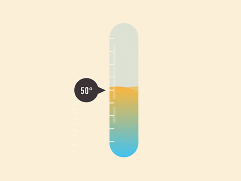

## Methods

A portable Arduino-based temperature data acquisition system (DAQ) was constructed to enable recording of body axial temperature data over the course of 15 minutes for one designated team member from each of the 10 groups in the BIOL3140-2021 class at two different times: one at around 4 am, when the subject was least active; and the other while the subject was most active at some point in the middle of the day. Once data had been acquired, it would then be joined to last year’s BIOL3140-2020 class data, composed of 30 subjects with the same relative two readings. A number of models describing the relationship between mass and the difference between the mean highest body temperature and mean lowest body temperature were put together for all 40 participants in the study. Likewise, once both the mean mass and mean difference between highest and lowest body temperatures for the 40 human subjects were calculated, these were added a to a larger dataset containing similar data from 51 species of non-human mammals from the study by Mortola and Lanthier, and new model describing the relationship between mass and the difference between the mean highest body temperature and mean lowest body temperature between different species was constructed.

Using our non-transformed data, we assessed if body temperature oscillations vary with mass using linear and non-linear allometric model analysis; first asking how well the data fits each model (in the context of least squares regression and residual magnitude). We then computed the AIC values of both of our models, compared their fits, and calculated the relative support of each model using AIC weights.

## Results

### Humans

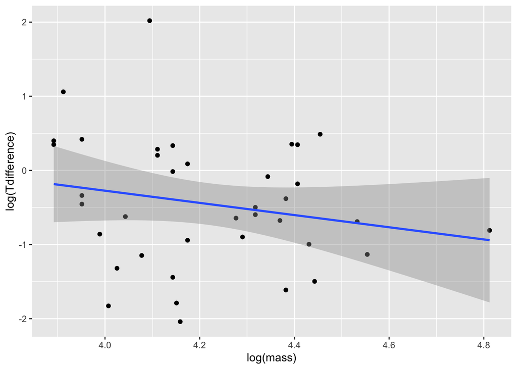

Log of change in temperature (C) between nighttime and daytime temp reading vs log of subject mass

AICc table of the comparison between linear and allometric models of the relationship between mass and change in temperature in humans

|  | df | AICc |
| --- | --- | --- |
| dat.log.lm | 3 | -142561.1 |
| dat.log.allo | 3 | -142697.7 |

AICw table of the comparison between linear and allometric models of the relationship between mass and change in temperature in humans

| fit | delta | w |
| --- | --- | --- |
| -142561.1 | 136.5972 | 0 |
| -142697.7 | 0.0000 | 1 |

### Other Mammals

#### Linear and allometric models mass vs change in temperature

AICc table of the comparison between linear and allometric models of the relationship between mass and change in temperature

|  | df | AICc |
| --- | --- | --- |
| mammal.lm | 3 | 91.73378 |
| mammal.allo | 3 | 98.29999 |

AICw table of the comparison between linear and allometric models of the relationship between mass and change in temperature

| fit | delta | w |
| --- | --- | --- |
| 91.73378 | 0.000000 | 0.9638446 |
| 98.29999 | 6.566206 | 0.0361554 |

#### Change in Temp vs Mass in Various Mammals

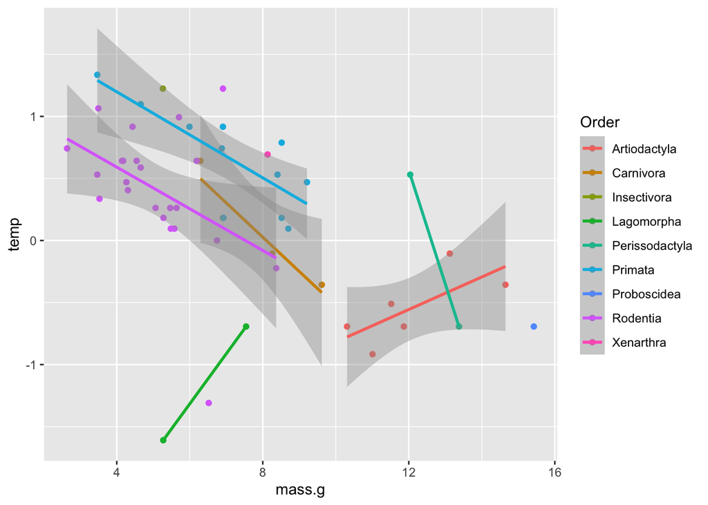

Log of change in Temp vs log of Mass in Various mammals

|  | df | AICc |
| --- | --- | --- |
| mammal.log.lm | 3 | 91.73378 |
| mammal.log.Order.lm | 16 | 80.94260 |

| fit | delta | w |
| --- | --- | --- |
| 91.73378 | 10.79118 | 0.004516 |
| 80.94260 | 0.00000 | 0.995484 |

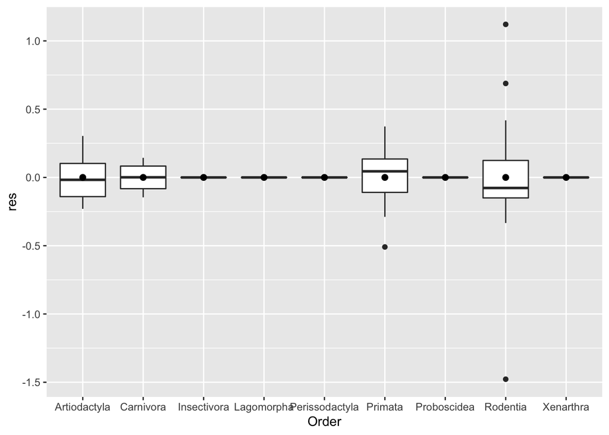

In human subjects, the relationship between change in temperature and mass is best modeled by an allometric model with log transformed data. Coefficient of scaling for Temp change vs mass in humans is -0.1227, and the slope is 4.222 for an allometric relationship. Slope for Temp change vs mass in humans is -.0971, and the y intercept is 3.95 for a linear relationship. In other mammals, the relationship between change in temperature and mass is best modeled by a linear model in log transformed data.Coefficient of scaling for Temp change vs mass in mammals is 7.284, and the slope is -1.840 for an allometric relationship. Slope for Temp change vs mass in mammals is -.1151 and y intercept is 1.071 for a linear relationship.

## Discussion

According to our last boxplot graph of the residuals, taxonomic group with respect to order predicts differences in this relationship across mammals.

## Author Contributions

In an effort to contribute to each other’s learning as a whole, Molecool team members worked together to crack the code, collecting data, assembling Arduino, and compiling an organized final .Rmd document. Team member Stephanie contributed by collecting her own data early in the morning and at night, cracking the code, and qualitatively assessing the effect of body temperature and mass in humans; team member Jessica contributed to the project by doing research to put together a comprehensive introduction, the bib file, citations, coding and csv file extraction and adjustments; team member Greg contributed to the project by collecting and organizing metadata, the Rmd file, as well as assessing the effect of body temperature and mass across humans and other mammals; team member Julia contributed to the project by doing csv file extraction and adjustments, writing up the methods, results, and discussion with citations.

## References

Angilletta Jr, Michael J, and Michael James Angilletta. 2009. “Thermal Adaptation: A Theoretical and Empirical Synthesis.”

Aschoff, J. 1982. “The Circadian Rhythm of Body Temperature as a Function of Body Size.” *A Companion to Animal Physiology*, 173–88.

Mortola, Jacopo P, and Clement Lanthier. 2004. “Scaling the Amplitudes of the Circadian Pattern of Resting Oxygen Consumption, Body Temperature and Heart Rate in Mammals.” *Comparative Biochemistry and Physiology Part A: Molecular & Integrative Physiology* 139 (1): 83–95.

Ostrowski, Stéphane, Joseph B Williams, and Khairi Ismael. 2003. “Heterothermy and the Water Economy of Free-Living Arabian Oryx (Oryx Leucoryx).” *Journal of Experimental Biology* 206 (9): 1471–78.